# **Applied Macroconomics Assignment 4**

## PART 1

Visible in the code file.

|  | zip | county_code | gagi_capita | gapp_capita | gmt | gamt | gnmt | q5irsinc_zill | hpi_growth | quantile |
| --- | --- | --- | --- | --- | --- | --- | --- | --- | --- | --- |
| 1 | 01001 | 25013 | 0.0262809079140425 | 0.0370581820607185 | 0.106398418545723 | 0.0749616995453835 | 0.0327031724154949 | 3 | 48.53 | fourth |
| 2 | 01002 | 25015 | 0.0668619573116302 | 0.0782261118292809 | 0.109302766621113 | 0.0862013921141624 | 0.0462251007556915 | 4 | 47.23 | third |
| 3 | 01005 | 25027 | 0.0237158760428429 | 0.0606555305421352 | 0.112972132861614 | 0.0474511720240116 | 0.0625860318541527 | 3 | 44.23 | third |
| 4 | 01007 | 25015 | 0.0341193303465843 | 0.0773104652762413 | 0.0495470315217972 | 0.0520420037209988 | -0.00136422319337726 | 4 | 46.94 | third |
| 5 | 01008 | 25013 | 0.0487665235996246 | 0.0381595678627491 | 0.0786406174302101 | 0.0380272306501865 | 0.0394158847630024 | 3 | 35.31 | third |
| 6 | 01010 | 25013 | 0.0673581808805466 | 0.0593674369156361 | -0.0238079726696014 | 0.0643649771809578 | -0.0828408822417259 | 4 | 44.13 | third |
| 7 | 01013 | 25013 | 0.032116673886776 | 0.040551520884037 | 0.173739895224571 | 0.0879702195525169 | 0.0898178517818451 | 1 | 52.29 | fourth |
| 8 | 01020 | 25013 | 0.0246185008436441 | 0.040343850851059 | 0.101074226200581 | 0.0705613866448402 | 0.0385076515376568 | 2 | 48.81 | fourth |
| 9 | 01022 | 25013 | 0.0159313920885324 | -0.0200217422097921 | 0.118894256651402 | 0.111848570406437 | 0.0537763833999634 | 2 |  | other |
| 10 | 01027 | 25015 | 0.0394832715392113 | 0.0435870140790939 | 0.107467442750931 | 0.0574890188872814 | 0.0484213009476662 | 3 | 52.89 | fourth |

[output cut: 8609 more lines]

## PART 2

It is apparent the the upper house price quantile experienced higher average annualized growth in total purchase mortgage origination as well as significantly higher average annualized growth in average purchase mortgage balance compared to the lowest house price quantile.

The lowest and second lowest house price quantiles experienced a higher growth in number of purchase mortgages originated from HMDA.

This evidence supports the findings of Adelino et al. (2016) where the authors state that subprime and poor borrowers were not the main drivers of the 2008 financial crisis: while middle and high-class borrowers experienced a lower pace of mortgage origination in terms of numbers of mortgages, the growth of the **value** of their new mortgages was higher. Since borrowers in low-income and subprime ZIP incomes obtain smaller mortgages on average, while the sheer number of them grew more, it did not have a significant effect on the overall distribution of credit.

Consequently, these findings reject Mian and Sufi’s (2009) supply-based hypothesis that *the expansion of credit to subprime borrowers may have been caused by an outward shift in the supply of mortgage credit by lenders* and their overall belief that subprime borrowers played the biggest part in the run-up to the crisis.

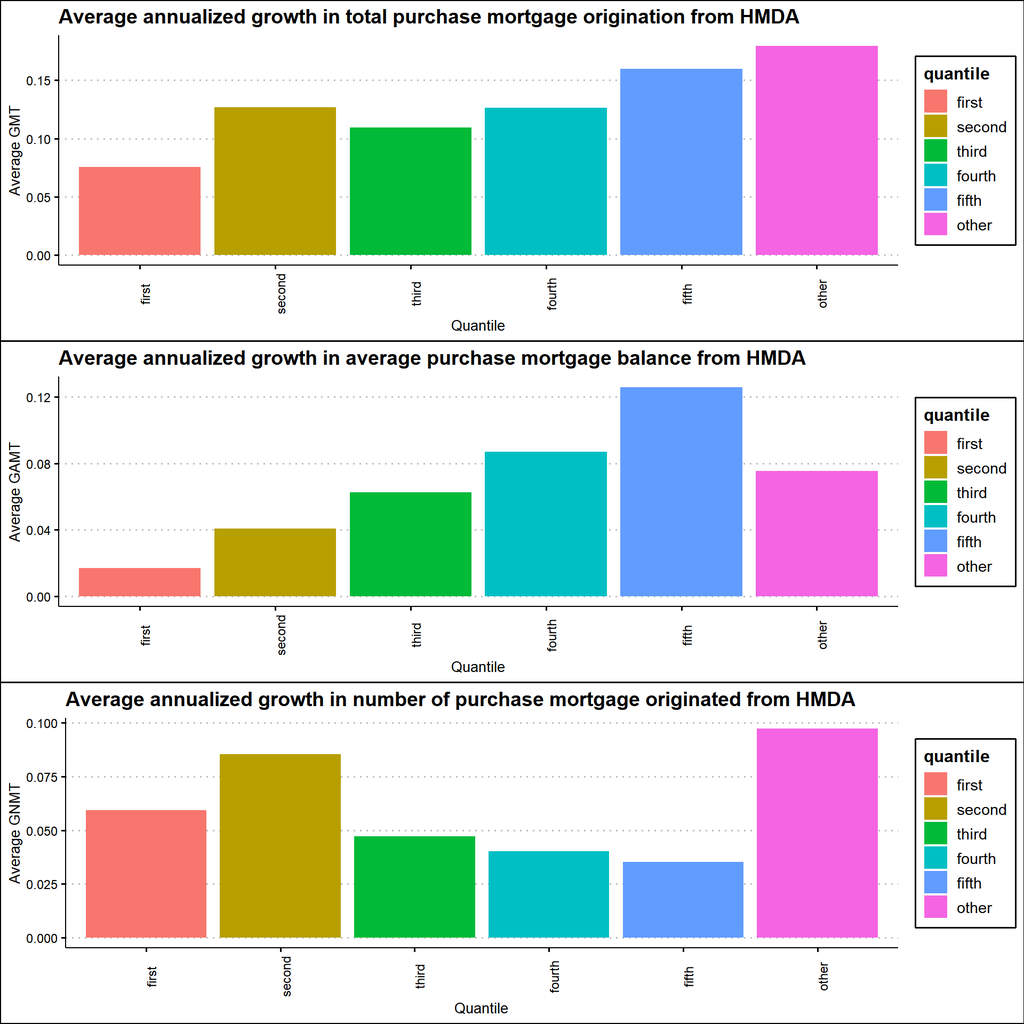

## PART 3

|  | quantile | q5irsinc_zill | average_gmt | average_gamt | average_gnmt |
| --- | --- | --- | --- | --- | --- |
| 1 | first | 1 | 0.0947 | 0.0239 | 0.072 |
| 2 | first | 2 | 0.0817 | 0.0189 | 0.0625 |
| 3 | first | 3 | 0.0677 | 0.0123 | 0.0555 |
| 4 | first | 4 | 0.0466 | 0.006 | 0.0425 |
| 5 | first | 5 | 0.074 | 0.0203 | 0.0548 |
| 6 | fifth | 1 | 0.2373 | 0.1337 | 0.0962 |
| 7 | fifth | 2 | 0.1813 | 0.1247 | 0.0547 |
| 8 | fifth | 3 | 0.1533 | 0.1166 | 0.0373 |
| 9 | fifth | 4 | 0.1174 | 0.1194 | 0.0023 |
| 10 | fifth | 5 | 0.0907 | 0.1335 | -0.0306 |

### Visual comparison:

We can see that averaged annualized growth in total purchase origination was higher for the upper house price quantile for all income quintiles. The same thing can be said about the average annualized growth in average purchase mortgage balance - it is significantly higher for the upper quantile.

The case is, again, different for the annualized growth in number of purchase mortgages originated, where the top house price growth quantile only exceeds the lowest quantile for the lowest income quintile and is even negative for the top income quintile.

This means that while the subpar borrowers saw a higher growth in number of mortgages, the growth in terms of value was significantly higher for the top house price quintile. Thus, while we can see where Mian and Sufi (2009) drew their inferences from, it is also clear that Adelino et al. (2016) were right in their refutal of the aforementioned authors.

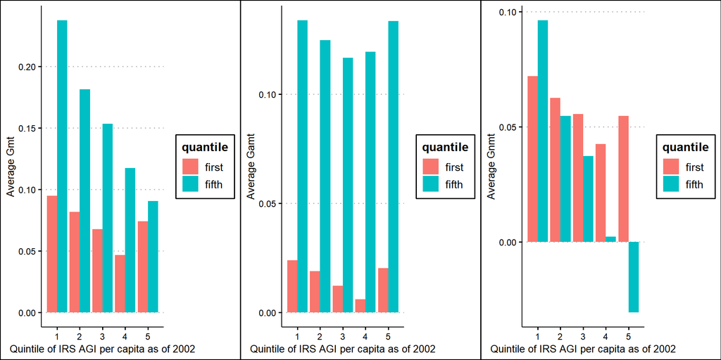

## PART 4

|  | *Dependent variable:* |  |  |
| --- | --- | --- | --- |
|  | gmt |  |  |
|  | *normal* | *panel* |  |
|  |  | *linear* |  |
|  | (1) | (2) | (3) |
| gagi_capita | 0.368*** | -0.182*** | 1.800*** |
|  | (0.057) | (0.057) | (0.222) |
| Constant | 0.105*** |  | 0.067*** |
|  | (0.003) |  | (0.011) |
| Observations | 8,619 | 8,619 | 882 |
| R<sup>2</sup> |  | 0.001 | 0.070 |
| Adjusted R<sup>2</sup> |  | -0.113 | 0.069 |
| Log Likelihood | 4,253.147 |  |  |
| Akaike Inf. Crit. | -8,502.293 |  |  |
| F Statistic |  | 10.033*** (df = 1; 7736) | 65.947*** (df = 1; 880) |
| *Note:* | p<0.1; p<0.05; p<0.01 |  |  |

|  | *Dependent variable:* |  |  |
| --- | --- | --- | --- |
|  | gamt |  |  |
|  | *normal* | *panel* |  |
|  |  | *linear* |  |
|  | (1) | (2) | (3) |
| gagi_capita | 0.587*** | 0.239*** | 0.994*** |
|  | (0.020) | (0.015) | (0.078) |
| Constant | 0.040*** |  | 0.017*** |
|  | (0.001) |  | (0.004) |
| Observations | 8,619 | 8,619 | 882 |
| R<sup>2</sup> |  | 0.034 | 0.155 |
| Adjusted R<sup>2</sup> |  | -0.077 | 0.154 |
| Log Likelihood | 13,347.830 |  |  |
| Akaike Inf. Crit. | -26,691.670 |  |  |
| F Statistic |  | 269.349*** (df = 1; 7736) | 160.893*** (df = 1; 880) |
| *Note:* | p<0.1; p<0.05; p<0.01 |  |  |

|  | *Dependent variable:* |  |  |
| --- | --- | --- | --- |
|  | gnmt |  |  |
|  | *normal* | *panel* |  |
|  |  | *linear* |  |
|  | (1) | (2) | (3) |
| gagi_capita | -0.218*** | -0.402*** | 0.672*** |
|  | (0.050) | (0.051) | (0.194) |
| Constant | 0.065*** |  | 0.053*** |
|  | (0.003) |  | (0.009) |
| Observations | 8,619 | 8,619 | 882 |
| R<sup>2</sup> |  | 0.008 | 0.013 |
| Adjusted R<sup>2</sup> |  | -0.105 | 0.012 |
| Log Likelihood | 5,431.513 |  |  |
| Akaike Inf. Crit. | -10,859.030 |  |  |
| F Statistic |  | 62.766*** (df = 1; 7736) | 12.027*** (df = 1; 880) |
| *Note:* | p<0.1; p<0.05; p<0.01 |  |  |

The first three regressions concern gmt, annualized growth in total purchase origination. In the first regression we can see that the coefficient on gagi_capita, annualized growth in IRS Adjusted Gross Income per capita, is positive and statistically significant. This works against Mian and Sufi’s (2009) theory that during the years in question income growth was decoupled from mortgage growth. The second regression includes county fixed effects as proposed by Mian and Sufi (2009) - the coefficient is negative and significant. However, using between-county variation, which is feasible due to there being significant variation accross counties, results in an again strongly positive and statistically significant coefficient.

Finally, the last three regressions test the relation between gnmt, annualized growth in number of purchase mortgages originated, and annualized growth in per-capita income. We see that including variation between counties overturns the negative within-county coefficient.

These results highlight the role of macroprudential regulation policy in containing the credit boom, as they disprove the hypothesis that income growth became decoupled from mortgage origination growth during the period of 2002-2006. In fact, they show that higher income growth had a positive relationship with mortgage value growth. This works against the idea that subprime borrowers were the main driver behind the financial crisis. That implies that simply filtering out low-income or low-credit score borrowers would not have solved the problem, as middle and high-income growth borrowers played a big part. They likely would not have been flagged as risky by any micro-level screening, and yet constituted a great part of mortgage balance growth.

## PART 5

The lower price sample consists of counties in the first house price growth quantile, whereas the higher price growth sample consists of counties in the top house price growth quantile.

### Counties with lower house price growth:

We see positive and statistically significant coefficients on almost all of the models. Therefore, we see that the income decoupling from income is not prevalent for the lower house price growth group.

|  | *Dependent variable:* |  |  |
| --- | --- | --- | --- |
|  | gmt |  |  |
|  | *normal* | *panel* |  |
|  |  | *linear* |  |
|  | (1) | (2) | (3) |
| gagi_capita | 1.191*** | 0.259 | 2.146*** |
|  | (0.172) | (0.177) | (0.492) |
| Constant | 0.036*** |  | 0.042** |
|  | (0.007) |  | (0.020) |
| Observations | 1,671 | 1,671 | 330 |
| R<sup>2</sup> |  | 0.002 | 0.055 |
| Adjusted R<sup>2</sup> |  | -0.244 | 0.052 |
| Log Likelihood | 834.033 |  |  |
| Akaike Inf. Crit. | -1,664.065 |  |  |
| F Statistic |  | 2.161 (df = 1; 1340) | 19.044*** (df = 1; 328) |
| *Note:* | p<0.1; p<0.05; p<0.01 |  |  |

|  | *Dependent variable:* |  |  |
| --- | --- | --- | --- |
|  | gamt |  |  |
|  | *normal* | *panel* |  |
|  |  | *linear* |  |
|  | (1) | (2) | (3) |
| gagi_capita | 0.462*** | 0.233*** | 0.524*** |
|  | (0.043) | (0.044) | (0.122) |
| Constant | 0.001 |  | 0.008* |
|  | (0.002) |  | (0.005) |
| Observations | 1,671 | 1,671 | 330 |
| R<sup>2</sup> |  | 0.020 | 0.053 |
| Adjusted R<sup>2</sup> |  | -0.221 | 0.050 |
| Log Likelihood | 3,132.138 |  |  |
| Akaike Inf. Crit. | -6,260.277 |  |  |
| F Statistic |  | 27.466*** (df = 1; 1340) | 18.490*** (df = 1; 328) |
| *Note:* | p<0.1; p<0.05; p<0.01 |  |  |

|  | *Dependent variable:* |  |  |
| --- | --- | --- | --- |
|  | gnmt |  |  |
|  | *normal* | *panel* |  |
|  |  | *linear* |  |
|  | (1) | (2) | (3) |
| gagi_capita | 0.658*** | -0.008 | 1.454*** |
|  | (0.150) | (0.156) | (0.426) |
| Constant | 0.037*** |  | 0.038** |
|  | (0.006) |  | (0.017) |
| Observations | 1,671 | 1,671 | 330 |
| R<sup>2</sup> |  | 0.00000 | 0.034 |
| Adjusted R<sup>2</sup> |  | -0.246 | 0.031 |
| Log Likelihood | 1,064.623 |  |  |
| Akaike Inf. Crit. | -2,125.247 |  |  |
| F Statistic |  | 0.003 (df = 1; 1340) | 11.651*** (df = 1; 328) |
| *Note:* | p<0.1; p<0.05; p<0.01 |  |  |

### Counties with higher house price growth:

|  | *Dependent variable:* |  |  |
| --- | --- | --- | --- |
|  | gmt |  |  |
|  | *normal* | *panel* |  |
|  |  | *linear* |  |
|  | (1) | (2) | (3) |
| gagi_capita | -0.135 | -0.330** | 0.459 |
|  | (0.136) | (0.147) | (0.360) |
| Constant | 0.167*** |  | 0.151*** |
|  | (0.008) |  | (0.021) |
| Observations | 1,670 | 1,670 | 178 |
| R<sup>2</sup> |  | 0.003 | 0.009 |
| Adjusted R<sup>2</sup> |  | -0.116 | 0.004 |
| Log Likelihood | 666.662 |  |  |
| Akaike Inf. Crit. | -1,329.323 |  |  |
| F Statistic |  | 5.021** (df = 1; 1491) | 1.623 (df = 1; 176) |
| *Note:* | p<0.1; p<0.05; p<0.01 |  |  |

|  | *Dependent variable:* |  |  |
| --- | --- | --- | --- |
|  | gamt |  |  |
|  | *normal* | *panel* |  |
|  |  | *linear* |  |
|  | (1) | (2) | (3) |
| gagi_capita | 0.349*** | 0.251*** | 0.690*** |
|  | (0.033) | (0.033) | (0.097) |
| Constant | 0.108*** |  | 0.086*** |
|  | (0.002) |  | (0.006) |
| Observations | 1,670 | 1,670 | 178 |
| R<sup>2</sup> |  | 0.037 | 0.225 |
| Adjusted R<sup>2</sup> |  | -0.078 | 0.220 |
| Log Likelihood | 3,006.413 |  |  |
| Akaike Inf. Crit. | -6,008.827 |  |  |
| F Statistic |  | 57.464*** (df = 1; 1491) | 51.050*** (df = 1; 176) |
| *Note:* | p<0.1; p<0.05; p<0.01 |  |  |

|  | *Dependent variable:* |  |  |
| --- | --- | --- | --- |
|  | gnmt |  |  |
|  | *normal* | *panel* |  |
|  |  | *linear* |  |
|  | (1) | (2) | (3) |
| gagi_capita | -0.435*** | -0.523*** | -0.242 |
|  | (0.119) | (0.128) | (0.318) |
| Constant | 0.058*** |  | 0.063*** |
|  | (0.007) |  | (0.018) |
| Observations | 1,670 | 1,670 | 178 |
| R<sup>2</sup> |  | 0.011 | 0.003 |
| Adjusted R<sup>2</sup> |  | -0.107 | -0.002 |
| Log Likelihood | 883.042 |  |  |
| Akaike Inf. Crit. | -1,762.084 |  |  |
| F Statistic |  | 16.763*** (df = 1; 1491) | 0.578 (df = 1; 176) |
| *Note:* | p<0.1; p<0.05; p<0.01 |  |  |